# Lab 7

Tianhao Jiang

I chose the high-pT samples.

```python
# import libraries
import pickle
import numpy as np
import matplotlib
import matplotlib.cm as cm
import matplotlib.pyplot as plt
import scipy
import math
import h5py
from scipy import stats
from scipy import signal
from math import floor

#this sets the size of the plot to something useful
plt.rcParams["figure.figsize"] = (20,15)
```

```python
# open the file of interest, and use pickle loading
infile = open ("Sample_pt_1000_1200/qcd_100000_pt_1000_1200.pkl",'rb')
qcd = pickle.load(infile)
infile = open ("Sample_pt_1000_1200/higgs_100000_pt_1000_1200.pkl",'rb')
higgs = pickle.load(infile)

# list all keys of the files
print('Variables in data:')
#print(qcd.keys())
print(higgs.keys())

# Number of data points
n_total = len(higgs['mass']) # = 100000

# Expected yields:
n_higgs = 50
n_qcd = 2000
```

```
Variables in data:
Index(['pt', 'eta', 'phi', 'mass', 'ee2', 'ee3', 'd2', 'angularity', 't1',
       't2', 't3', 't21', 't32', 'KtDeltaR'],
      dtype='object')
```

**1. Make a stacked histogram plot for the feature variable: mass**

```python
def compare(ax, signal, bkgd, param, sigmas = 4, num_bins = 200,fontsize = 20):
    left1 = np.min([np.min(bkgd),np.min(signal)])
    left2 = np.min([np.mean(bkgd)-sigmas*np.std(bkgd), np.mean(signal)-sigmas*np.std(signal)])
    left = np.max([left1,left2])
    right1 = np.max([np.max(bkgd),np.max(signal)])
    right2 = np.max([np.mean(bkgd)+sigmas*np.std(bkgd), np.mean(signal)+sigmas*np.std(signal)])
    bins = np.linspace(np.max([left1,left2]),np.min([right1,right2]),num_bins)
    ax.hist([signal,bkgd], bins=bins, alpha = 0.5, color= ['r','b'], stacked = True,\
            label = ['Signal','Background'], ls='dashed', weights = [[n_higgs/n_total]*len(signal),[n_qcd/n_total]*len(bkgd)])
    #ax.hist(signal, bins=bins, alpha = 0.5,color= 'r',label = 'Signal', weights = [n_higgs/n_total]*len(signal))
    ax.legend(prop={'size': fontsize})
    ax.set_ylabel("Counts",fontsize=fontsize)
    ax.set_xlabel(param,fontsize=fontsize)
    ax.set_title('Stacked histograms of %s' % param,fontsize=int(fontsize*1.25))
```

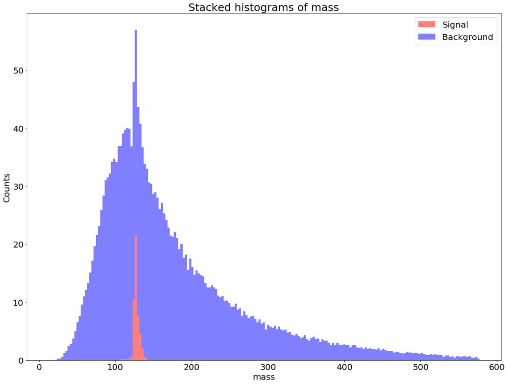

```python
plt.rcParams.update({'font.size': 20})

fig, ax = plt.subplots()
param = 'mass'
compare(ax, higgs[param], qcd[param], param, fontsize = 20)
plt.show()
```

- **Evaluate expected significance without any event selection.**
  - **Use Poisson statistics for significance calculation:**
  - **Compare your number of N_Higgs/(√N_QCD) . If they are equivalent, explain your findings.**

The expected yields of the background and the signal are 2000 and 50, respectively. We are assuming the background follows a Poission distribution with a mean of 2000. So the significance is probability of observing a background yield equal to or larger than 2000 + 50 = 2050:

```python
prob = 1 - stats.poisson.cdf(2050,2000)
sigmas = stats.norm.ppf(1-prob)
print('The expected significance is %.5f-sigmas.' % sigmas)
```

```
The expected significance is 1.12822-sigmas.
```

```python
result = n_higgs/np.sqrt(n_qcd)
print('My number of N_Higgs/(√N_QCD) is %.5f.' % result)
```

```
My number of N_Higgs/(√N_QCD) is 1.11803.
```

This N_Higgs/(√N_QCD) value is close to the significance value of 1.12822 I found above.

The value of 1.11803 is the significance we would get if the background is exactly a Gaussian distribution with mean = 2000 and variance = 2000. And 1.12822 is what we get from our actual background, which is a Poisson distribution with mean = 2000 and variance = 2000.

A Poisson distribution with a large mean value would resemble a Gaussian distribution. And our mean of 2000 is relatively large. Thus the two values are approximately equivalent.

**1. Identify mass cuts to optimize the expected significance.**

- **Try different mass cuts systematically**
  - **Evaluate expeced significance for each set of mass cuts**
  - **Identify the set of the mass cuts which give you the highest significance.**

Based on the observation that almost all of the variables' histograms are single-peaked, I think it's natural to assume that the optimal set of cuts on each of the variables would contain two cuts x1 and x2, where x1 < x2, and we would discard the data with its corresponding variable smaller than x1 or larger than x2.

Based on this assumption, I wrote a few Python functions below to facilitate the process of finding cuts.

```python
# Returns the emperical CDF at points x given data.
# Function assumes x is a sorted array
def ecdf(data, x):
    data_size = len(data)
    data1 = sorted(data)
    result = np.zeros(len(x))
    j = 0
    for i in range(0,len(x)):
        while (j < data_size) and (data1[j] <= x[i]):
            j = j + 1
        result[i] = j
    result = result / data_size
    return result

# Returns four 2D arrays: X1,X2,s_diff,b_diff
# [X1,X2] is the meshgrid formed by the linear spaces x1 and x2=x1
# s_diff and b_diff are the ratio of the data and background with values between x1 and x2
# x1 should be a sorted array
def cut(signal,bkgd,x1):
    s = ecdf(signal,x1) # s is the emperical CDF of signal as a function of x1
    b = ecdf(bkgd,x1) # b is the emperical CDF of background as a function of x1
    X1,X2 = np.meshgrid(x1,x1)
    s_x1,s_x2 = np.meshgrid(s,s)
    b_x1,b_x2 = np.meshgrid(b,b)
    s_diff = s_x2 - s_x1
    b_diff = b_x2 - b_x1
    b_diff[b_diff==0] = 1e-12 # so that we don't divide by zero
    s_diff[X1>=X2] = 0 # ignore values with their x1>=x2
    b_diff[X1>=X2] = 1e-12 # ignore values with their x1>=x2
    significance = (s_diff*len(signal)/n_total*n_higgs)/np.sqrt(b_diff*len(bkgd)/n_total*n_qcd)
    return X1,X2,s_diff,b_diff,significance

# Determines x1 automatically
# bin_per_sd: bins per standard deviation of signal
def cut2(signal,bkgd,bins_per_sd):
    mean = np.mean(signal)
    sd = np.std(signal)
    step_size = sd/bins_per_sd
    x1 = np.arange(mean-5*sd,mean+5*sd+step_size,step_size)
    return cut(signal,bkgd,x1)


# Plots on ax the significance of signal and the ratio of signal left (s_diff)
# when we cut out sigal and background smaller than X1 and larger than X2
def plot_cuts(ax,X1,X2,significance,s_diff):
    #print(s_diff)
    left = X1[0,0]
    right = X1[0,len(X1)-1]
    im = ax.imshow(s_diff, origin='lower', extent=(left,right,left,right), cmap=cm.gnuplot2)
    CS = ax.contour(X1, X2, significance, linewidths=3,cmap=cm.Reds)
    ax.clabel(CS, inline=1, fontsize=10)
    CB = fig.colorbar(CS, shrink=0.8, extend='both')
    CBI = fig.colorbar(im, orientation='horizontal', shrink=0.8)
    l, b, w, h = ax.get_position().bounds
    CB.ax.set_position([l+w*1.2, b, w, h])
    CBI.ax.set_position([l, b-h*1.1, w, h])
    CB.set_label('Significance = N_Higgs/(√N_QCD)', fontsize = 15)
    CBI.set_label('Ratio of signal remaining', fontsize=15)

    plt.grid(b=True, which='major', color='#009900', linestyle='-',linewidth=1)
    plt.minorticks_on()
    plt.grid(b=True, which='minor', color='#009900', linestyle='-', alpha=0.3)
    ax.set_xlabel('x1, left cut location', fontsize=15)
    ax.set_ylabel('x2, right cut location', fontsize=15)

# For each minimum Ratio of signal remaining allowed in the array p_span,
# returns the location and significance of the cut with the hightest significance.
# p_span should be sorted
def best_cuts(p_span,X1,X2,significance,signal_remaining):
    size = len(X1)**2
    x1 = X1.reshape(1,size)[0]
    x2 = X2.reshape(1,size)[0]
    s = significance.reshape(1,size)[0]
    p = signal_remaining.reshape(1,size)[0]
    p1 = p[p!=0]
    permutation = sorted(range(len(p1)), key=p1.__getitem__)
    x1 = x1[p!=0][permutation]
    x2 = x2[p!=0][permutation]
    s = s[p!=0][permutation]
    p = p1[permutation]
    x1_result = np.zeros(len(p_span))
    x2_result = np.zeros(len(p_span))
    s_result = np.zeros(len(p_span))
    j = len(p) - 1
    result = j
    for i in range(len(p_span)-1,-1,-1):
        while (j >= 0) and (p[j] >= p_span[i]):
            if s[j] > s[result]:
                result = j
            j = j - 1
        x1_result[i] = x1[result]
        x2_result[i] = x2[result]
        s_result[i] = s[result]
    return x1_result, x2_result, s_result
```

I plotted the significance of observation and the ratio of data left when we select the data with its mass within the range of (x1, x2) as a function of x1, the location of the cut on the left, and x2, the location of the cut on the right.

```python
variable_name = 'mass'
X1,X2,s_diff,b_diff,significance = cut2(higgs[variable_name],qcd[variable_name],100)
```

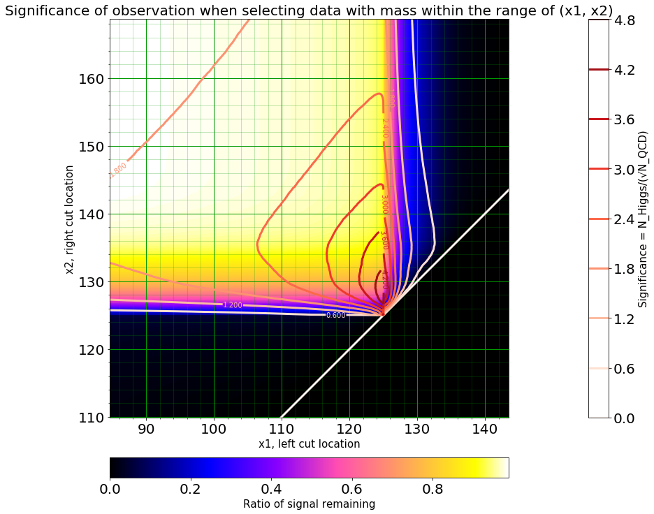

```python
# Make plot
fig, ax = plt.subplots()
plot_cuts(ax,X1,X2,significance,s_diff)
mean = np.mean(higgs[variable_name])
sd = np.std(higgs[variable_name])
ax.set_xlim([mean-5*sd,mean+2*sd])
ax.set_ylim([mean-2*sd,mean+5*sd])
ax.set_title('Significance of observation when selecting data with %s within the range of (x1, x2)' % variable_name, fontsize = 20)
plt.show()
```

The optimal set of cuts should give as high an expected significance as possible, while at the same time doesn't cause a loss of too many signals. From the graph above, we can see that the 4.2-sigmas significance countour is although small but possible to let us to keep most of our signals after the cuts. So our best set of mass cuts should lie somewhere within this countour.

To find out exactly where the best set of cuts is at, I plotted below the the maximum significance achievable as a function of the minimum ratio of signal remaining allowed.

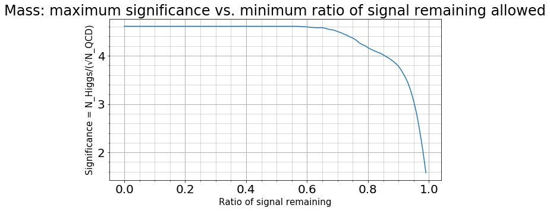

```python
p_span = np.arange(0,1,0.01)
x1_p,x2_p,significance_p = best_cuts(p_span,X1,X2,significance,s_diff)

fig, ax = plt.subplots(figsize = (10,5))
ax.plot(p_span,significance_p)
ax.set_xlabel('Ratio of signal remaining', fontsize=15)
ax.set_ylabel('Significance = N_Higgs/(√N_QCD)', fontsize=15)
ax.set_title('Mass: maximum significance vs. minimum ratio of signal remaining allowed')
plt.grid(b=True, which='major', linestyle='-',linewidth=1)
plt.minorticks_on()
plt.grid(b=True, which='minor', linestyle='-',linewidth=0.5)
plt.show()
```

We can see the highest possible significance is about 4.6-sigmas, and we can keep at most about 60% of our data to achieve this significance. 60 percent is not very low, so we may say this 4.6-sigmas set of cuts is the best.

```python
mass_cuts = x1_p[0],x2_p[0]
_,_,s_diff2,_,significance2 = cut(higgs["mass"],qcd["mass"],mass_cuts)
print("My optimal set of mass cuts: (left, right) = %s" % str(mass_cuts))
print("Significance after the cuts: %.5f-sigmas" % significance2[1,0])
print("Ratio of signal remaining: %s" %  "{0:.2%}".format(s_diff2[1,0]))

signal_cuts_1 = (higgs["mass"]>=mass_cuts[0])&(higgs["mass"]<=mass_cuts[1])
bkgd_cuts_1 = (qcd["mass"]>=mass_cuts[0])&(qcd["mass"]<=mass_cuts[1])
```

```
My optimal set of mass cuts: (left, right) = (124.98224260383364, 128.09318340257153)
Significance after the cuts: 4.60931-sigmas
Ratio of signal remaining: 57.38%
```

**3. Make stacked histogram plots for the reset of features**

- **Set A of plots without any event selection**
  - **Can you identify another feature as discriminative as mass feature (i.e. equal or better significance after feature cut)?**

I still included mass in the features for comparison

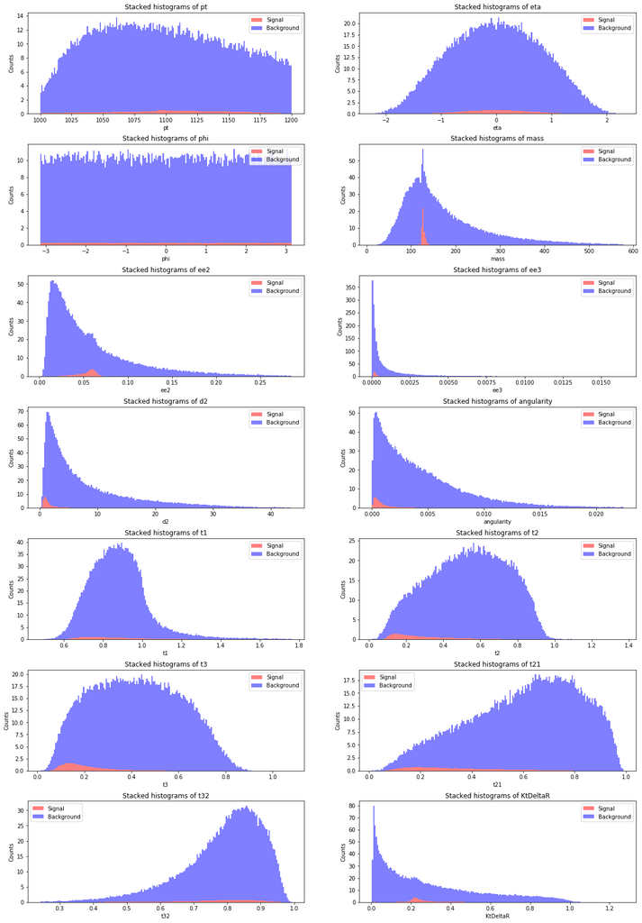

```python
plt.rcParams.update({'font.size': 10})
fig, axs = plt.subplots(7, 2, figsize=(20,30))
plt.subplots_adjust(left=None, bottom=None, right=None, top=None, wspace=None, hspace=.3)
i = 0
for param in higgs.keys():
    ax = axs[int(i/2),i%2]
    compare(ax, higgs[param], qcd[param], param, fontsize = 10)
    #ax.set_yscale("log")
    i = i+1
plt.show()
```

It seems the features ee2, t2, t3, and KtDeltaR may be as discriminative as the mass feature.

To see their discriminative powers numerically, I calculated the maximum significance achivable by applying cuts on each of these features.

```python
print("Max possible significances:")
for param in higgs.keys():
    X1,X2,s_diff,b_diff,significance = cut2(higgs[param],qcd[param],10)
    print("%s: %.3f" % (param,np.max(significance)))
```

```
Max possible significances:
pt: 1.133
eta: 1.210
phi: 1.118
mass: 4.599
ee2: 2.147
ee3: 1.866
d2: 2.045
angularity: 1.766
t1: 1.118
t2: 1.845
t3: 1.861
t21: 1.826
t32: 1.130
KtDeltaR: 2.079
```

None of the rest of the parameters has a significance value higher than that of mass.

So no other feature is as discriminative as the mass feature.

- **Set B of plots with your optimal mass cuts**
  - **Can you identify additional feature to further imrpove expected signifiance?**

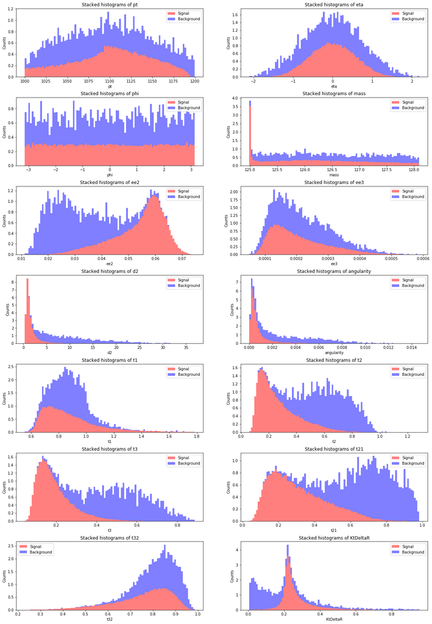

```python
plt.rcParams.update({'font.size': 10})
fig, axs = plt.subplots(7, 2, figsize=(20,30))
plt.subplots_adjust(left=None, bottom=None, right=None, top=None, wspace=None, hspace=.3)
i = 0
for param in higgs.keys():
    ax = axs[int(i/2),i%2]
    compare(ax, higgs[param][signal_cuts_1], qcd[param][bkgd_cuts_1], param, fontsize = 10,num_bins = 100)
    #ax.set_yscale("log")
    i = i+1
plt.show()
```

Again, to find the best cuts quantitatively, I calculated the maximum significance achivable by applying cuts on each of these features (with the optimal mass cuts already applied). In these calculations, I set the limit that at 30% of signal must be left after the cuts to avoid deviding by zero.

```python
print("Max possible significances:")
for param in higgs.keys():
    X1,X2,s_diff,b_diff,sig = cut2(higgs[param][signal_cuts_1],qcd[param][bkgd_cuts_1],10)
    sig1 = sig[s_diff >= 0.3] # ratio of signal count before and after the cuts >= 30%
    maxs = np.max(sig1)
    print("%s: %.3f" % (param,maxs))
    #print(X1[sig == maxs][0], X2[sig == maxs][0], s_diff[sig == maxs][0],b_diff[sig == maxs][0])
```

```
Max possible significances:
pt: 4.692
eta: 5.029
phi: 4.609
mass: 4.609
ee2: 17.032
ee3: 4.617
d2: 61.430
angularity: 8.970
t1: 4.601
t2: 21.372
t3: 24.002
t21: 17.386
t32: 4.792
KtDeltaR: 8.789
```

Plot the the maximum significance vs. ratio of signal remaining for the d2 feature:

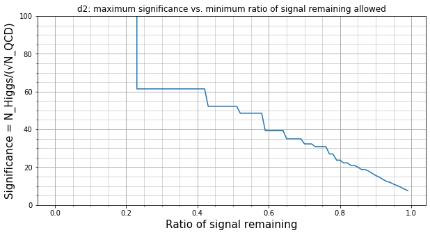

```python
param = 'd2'
signal = higgs[param][signal_cuts_1]
bkgd = qcd[param][bkgd_cuts_1]
X1,X2,s_diff,b_diff,significance = cut2(signal,bkgd,10)
p_span = np.arange(0,1,0.01)
x1_p,x2_p,significance_p = best_cuts(p_span,X1,X2,significance,s_diff)

fig, ax = plt.subplots(figsize = (10,5))
ax.plot(p_span,significance_p)
ax.set_xlabel('Ratio of signal remaining', fontsize=15)
ax.set_ylabel('Significance = N_Higgs/(√N_QCD)', fontsize=15)
ax.set_title('d2: maximum significance vs. minimum ratio of signal remaining allowed')
ax.set_ylim(0,100)
plt.grid(b=True, which='major', linestyle='-',linewidth=1)
plt.minorticks_on()
plt.grid(b=True, which='minor', linestyle='-',linewidth=0.5)
plt.show()
x1_p[p_span>=0.4][0],x2_p[p_span>=0.4][0]
plt.show()
```

The max signifiance with 0 to 20 percent of signal remaining are infinity because of dividing by zero so are not shown here. The 61-sigmas significance corresponds to a ~40% of signal remaining, which seems to be a good choice.

```python
d2_cuts = x1_p[p_span>=0.4][0],x2_p[p_span>=0.4][0]
_,_,s_diff2,_,significance2 = cut(signal,bkgd,d2_cuts)
print("My optimal set of mass cuts: (left, right) = %s" % str(mass_cuts))
print("My optimal set of d2 cuts: (left, right) = %s" % str(d2_cuts))
print("Significance after mass and d2 cuts: %.5f-sigmas" % significance2[1,0])
print("Ratio of signal counts before and after d2 cuts: %s" %  "{0:.2%}".format(s_diff2[1,0]))
print("Ratio of signal counts before and after mass and d2 cuts: %s" %  "{0:.2%}".format(s_diff2[1,0]*len(signal)/n_total))

signal_cuts_2 = signal_cuts_1 & (higgs["d2"]>=d2_cuts[0]) & (higgs["d2"]<=d2_cuts[1])
bkgd_cuts_2 = bkgd_cuts_1 & (qcd["d2"]>=d2_cuts[0])&(qcd["d2"]<=d2_cuts[1])

print("\nNumber of background points left (out of %d points): %d" % (n_total, len(qcd['d2'][bkgd_cuts_2])))
```

```
My optimal set of mass cuts: (left, right) = (124.98224260383364, 128.09318340257153)
My optimal set of d2 cuts: (left, right) = (0.27837101274447207, 1.0504993443653543)
Significance after mass and d2 cuts: 61.43000-sigmas
Ratio of signal counts before and after d2 cuts: 42.82%
Ratio of signal counts before and after mass and d2 cuts: 24.57%

Number of background points left (out of 100000 points): 2
```

There are only two background data points left out of the original 100000, so it's not practical to make any further cuts.

The 61-sigmas significance value may not be very accurate since there are only 2 background points left.

Stacked histogram plots with cuts on both mass and d2 applied:

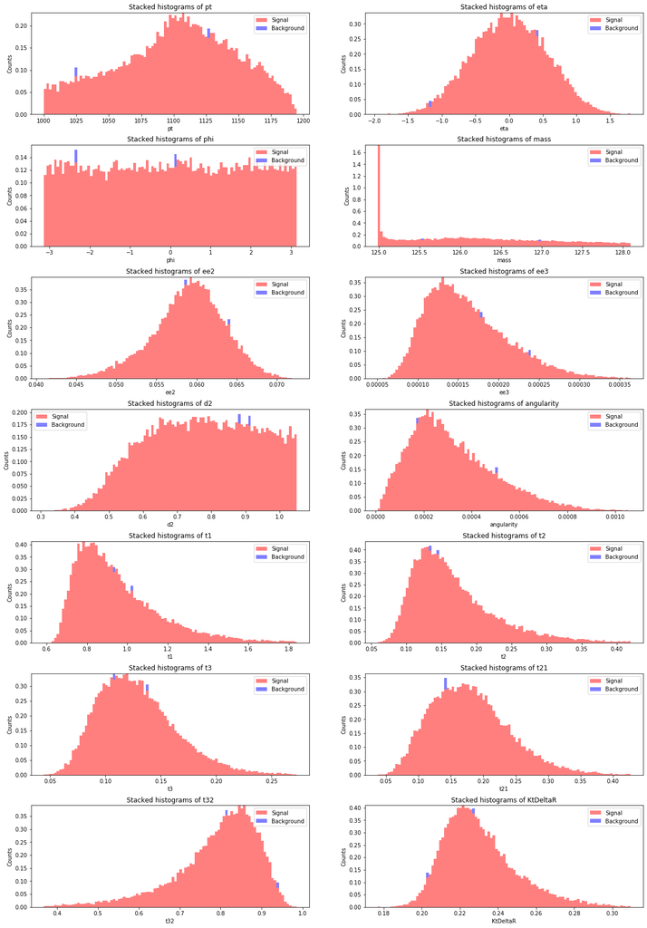

```python
plt.rcParams.update({'font.size': 10})
fig, axs = plt.subplots(7, 2, figsize=(20,30))
plt.subplots_adjust(left=None, bottom=None, right=None, top=None, wspace=None, hspace=.3)
i = 0
for param in higgs.keys():
    ax = axs[int(i/2),i%2]
    compare(ax, higgs[param][signal_cuts_2], qcd[param][bkgd_cuts_2], param, fontsize = 10,num_bins = 100)
    #ax.set_yscale("log")
    i = i+1
plt.show()
```